# Titanic Practice Exercise

Carme Mias

4 July 2020

Practice exercise based on the [Kaggle Titanic](https://www.kaggle.com/c/titanic/overview) dataset.

```r
training_data <- read.csv('data/train.csv')
head(training_data)
```

|  | PassengerId | Survived | Pclass | Name | Sex | Age | SibSp | Parch | Ticket | Fare | Cabin | Embarked |
| --- | --- | --- | --- | --- | --- | --- | --- | --- | --- | --- | --- | --- |
| 1 | 1 | 0 | 3 | Braund, Mr. Owen Harris | male | 22 | 1 | 0 | A/5 21171 | 7.2500 |  | S |
| 2 | 2 | 1 | 1 | Cumings, Mrs. John Bradley (Florence Briggs Thayer) | female | 38 | 1 | 0 | PC 17599 | 71.2833 | C85 | C |
| 3 | 3 | 1 | 3 | Heikkinen, Miss. Laina | female | 26 | 0 | 0 | STON/O2. 3101282 | 7.9250 |  | S |
| 4 | 4 | 1 | 1 | Futrelle, Mrs. Jacques Heath (Lily May Peel) | female | 35 | 1 | 0 | 113803 | 53.1000 | C123 | S |
| 5 | 5 | 0 | 3 | Allen, Mr. William Henry | male | 35 | 0 | 0 | 373450 | 8.0500 |  | S |
| 6 | 6 | 0 | 3 | Moran, Mr. James | male | NA | 0 | 0 | 330877 | 8.4583 |  | Q |

```r
str(training_data)
```

```
'data.frame':   891 obs. of  12 variables:
 $ PassengerId: int  1 2 3 4 5 6 7 8 9 10 ...
 $ Survived   : int  0 1 1 1 0 0 0 0 1 1 ...
 $ Pclass     : int  3 1 3 1 3 3 1 3 3 2 ...
 $ Name       : Factor w/ 891 levels "Abbing, Mr. Anthony",..: 109 191 358 277 16 559 520 629 417 581 ...
 $ Sex        : Factor w/ 2 levels "female","male": 2 1 1 1 2 2 2 2 1 1 ...
 $ Age        : num  22 38 26 35 35 NA 54 2 27 14 ...
 $ SibSp      : int  1 1 0 1 0 0 0 3 0 1 ...
 $ Parch      : int  0 0 0 0 0 0 0 1 2 0 ...
 $ Ticket     : Factor w/ 681 levels "110152","110413",..: 524 597 670 50 473 276 86 396 345 133 ...
 $ Fare       : num  7.25 71.28 7.92 53.1 8.05 ...
 $ Cabin      : Factor w/ 148 levels "","A10","A14",..: 1 83 1 57 1 1 131 1 1 1 ...
 $ Embarked   : Factor w/ 4 levels "","C","Q","S": 4 2 4 4 4 3 4 4 4 2 ...
```

# Explore the data

We’ll use the Amelia package for the exploration, useful for finding out how much data is missing from the dataset.

[output not shown]

## How much data is missing and for which variables?

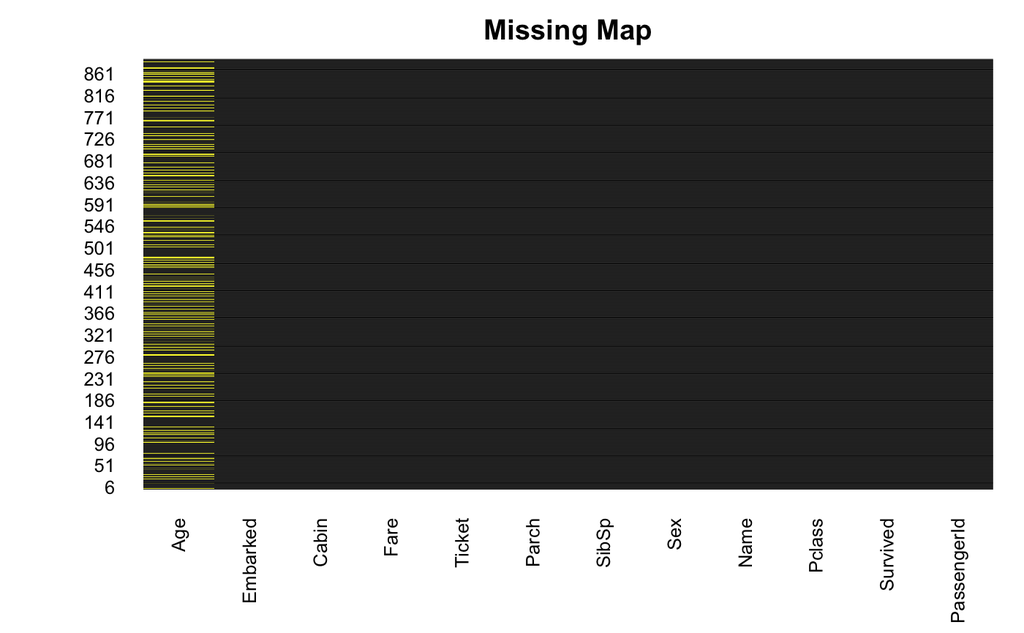

```r
Amelia::missmap(training_data, main = "Missing Map", col = c('yellow', 'black'), legend=FALSE)
```

We can see from the map that all of the missing data is in the age column. We can also find out what the proportion is of missing age data and, later on, we’ll need to decide a way to deal with it.

```r
proportion <- round(nrow(training_data[is.na(training_data$Age),]) * 100 /  nrow(training_data) , 2)
paste0("The proportion of missing values in the Age column is: ", proportion , " %" )
```

```
[1] "The proportion of missing values in the Age column is: 19.87 %"
```

## What was the make up of the passenger list?

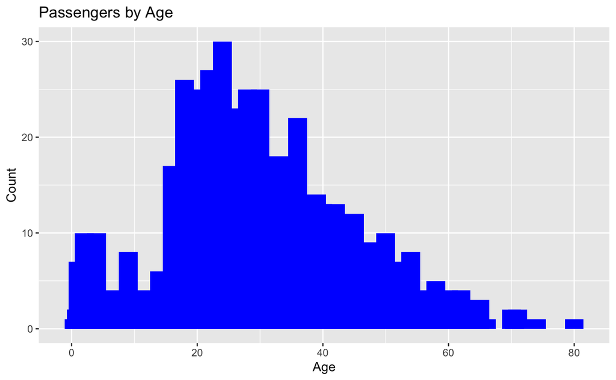

```r
ggplot(training_data, aes(x=Age)) + geom_bar(width = 3, fill='blue') +
  scale_y_continuous(breaks = seq(min(0), max(160), by=10)) +
  xlab( 'Age' ) + ylab( 'Count' ) + ggtitle( 'Passengers by Age' )
```

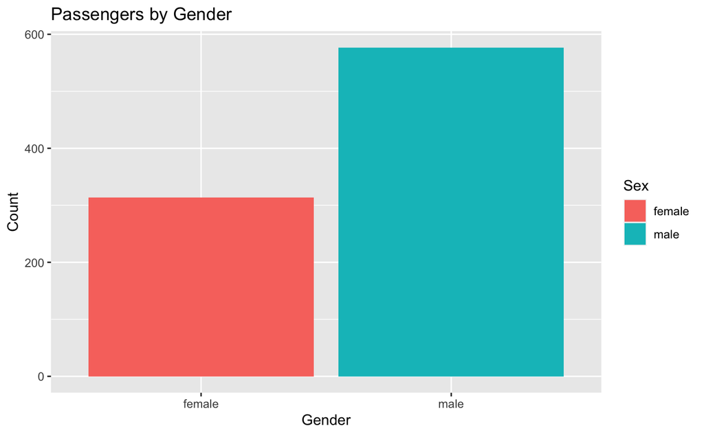

```r
ggplot(training_data, aes(x=Sex)) + geom_bar(aes(fill=Sex)) +
  xlab( 'Gender' ) + ylab( 'Count' ) + ggtitle( 'Passengers by Gender' )
```

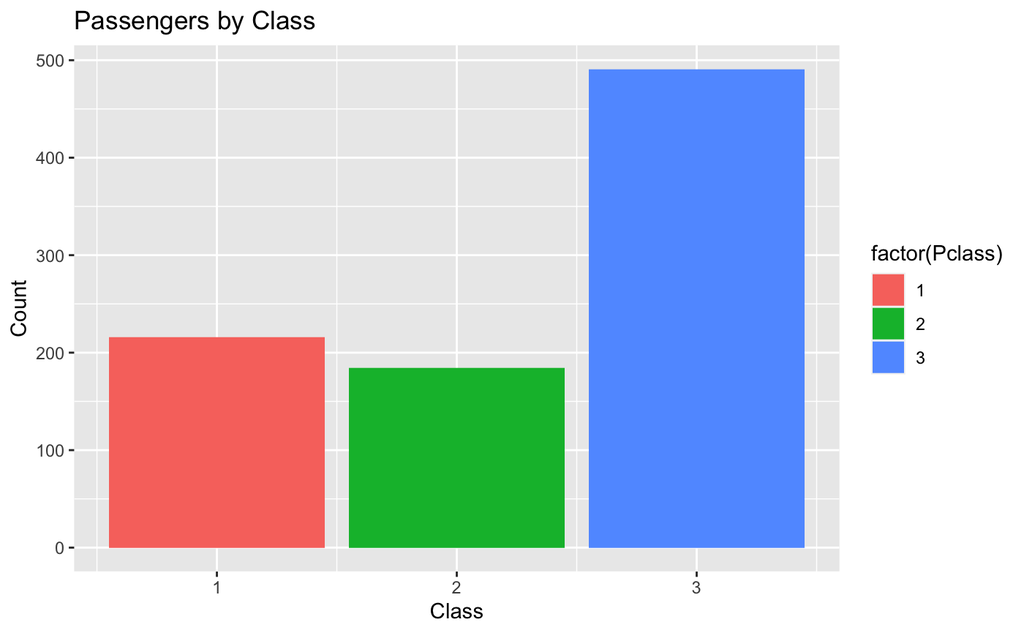

```r
ggplot(training_data, aes(x=Pclass)) + geom_bar(aes(fill=factor(Pclass))) +
  xlab( 'Class' ) + ylab( 'Count' ) + ggtitle( 'Passengers by Class' )
```

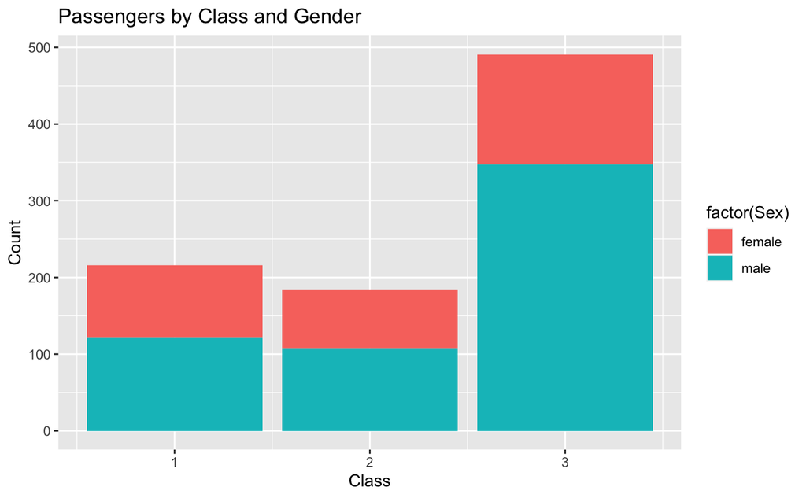

```r
ggplot(training_data, aes(x=Pclass)) + geom_bar(aes(fill=factor(Sex))) +
  xlab( 'Class' ) + ylab( 'Count' ) + ggtitle( 'Passengers by Class and Gender' )
```

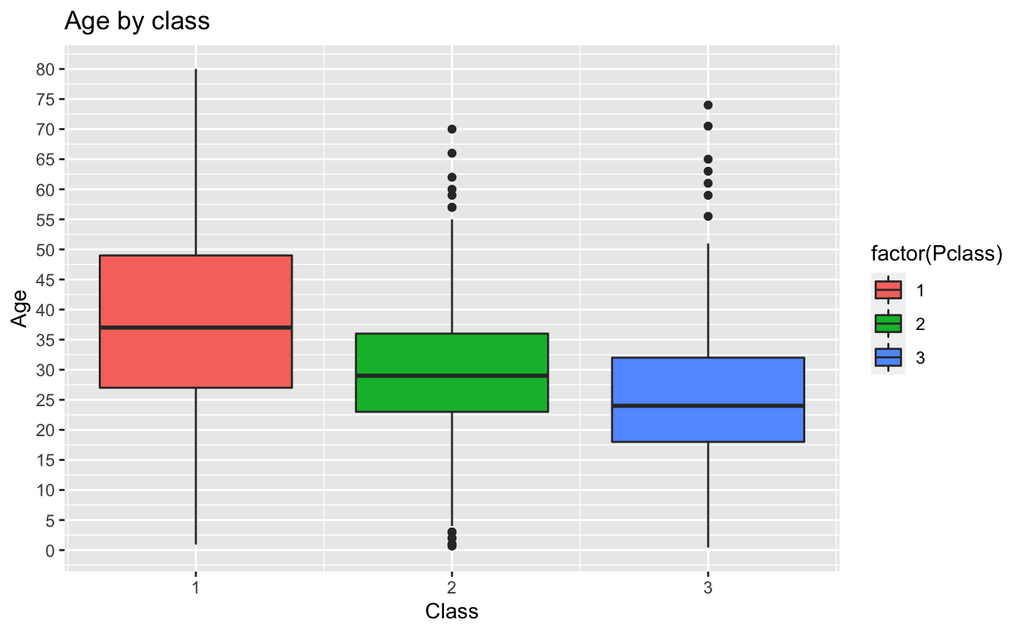

```r
ggplot(training_data, aes(x=Pclass, y=Age)) + geom_boxplot(aes(fill=factor(Pclass))) +
  scale_y_continuous(breaks = seq(min(0), max(80), by=5)) +
  xlab('Class') + ylab('Age') + ggtitle('Age by class')
```

## How many passengers were travelling with family?

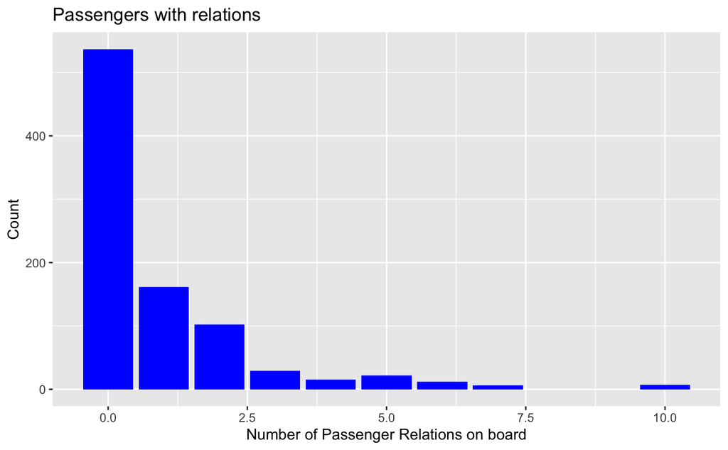

```r
ggplot(training_data, aes(x=(SibSp + Parch))) + geom_bar(fill='blue') +
  xlab( 'Number of Passenger Relations on board' ) + ylab( 'Count' ) + ggtitle( 'Passengers with relations' )
```

## How many people survived?

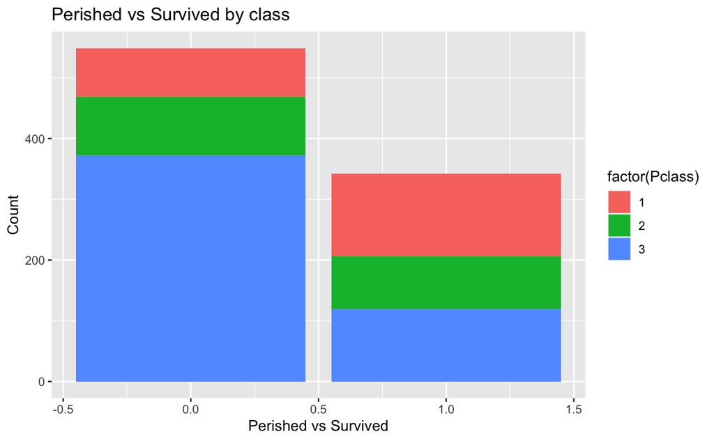

```r
ggplot(training_data, aes(x=Survived)) + geom_bar(aes(fill=factor(Pclass))) +
  xlab( 'Perished vs Survived' ) + ylab( 'Count' ) + ggtitle( 'Perished vs Survived by class' )
```

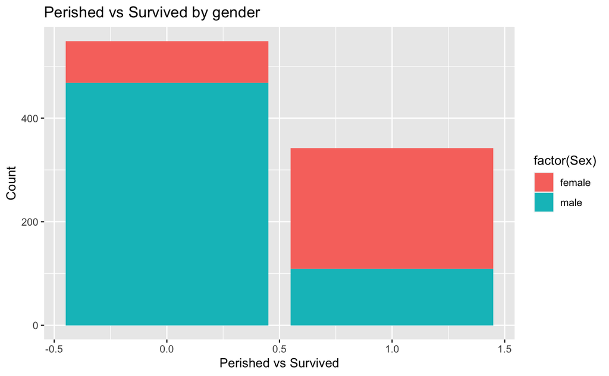

```r
ggplot(training_data, aes(x=Survived)) + geom_bar(aes(fill=factor(Sex))) +
  xlab( 'Perished vs Survived' ) + ylab( 'Count' ) + ggtitle( 'Perished vs Survived by gender' )
```

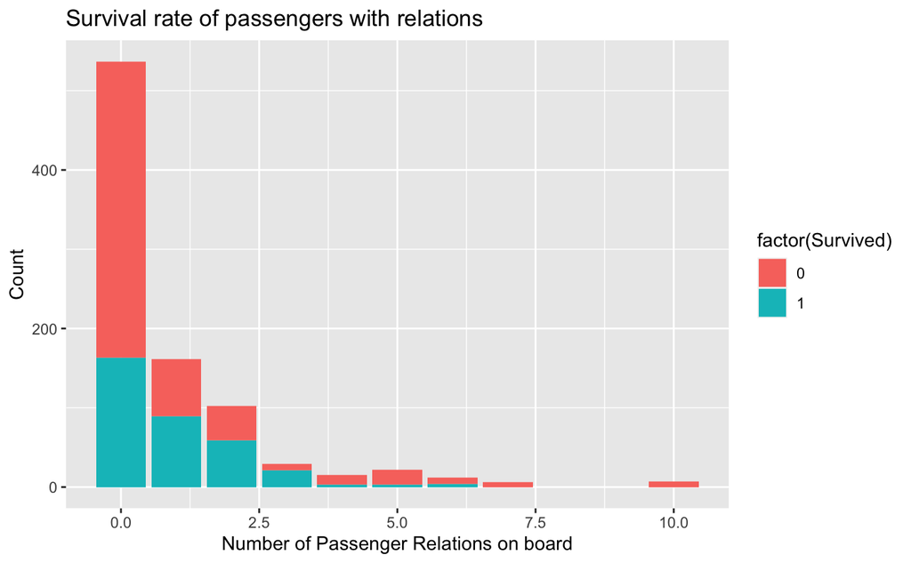

```r
ggplot(training_data, aes(x=(SibSp + Parch))) + geom_bar(aes(fill=factor(Survived))) +
  xlab( 'Number of Passenger Relations on board' ) + ylab( 'Count' ) + ggtitle( 'Survival rate of passengers with relations' )
```

# Imputation of Age variable

```r
calculate_mean <- function(data, cl) {
  floor(mean(subset(data, subset=(!is.na(Age) & Pclass == as.integer(cl)), select = Age)$Age))
  }

impute_age <- function(data,age,class) {
  class_1_mean <- calculate_mean(data, 1)
  class_2_mean <- calculate_mean(data, 2)
  class_3_mean <- calculate_mean(data, 3)
  out <- age
  for (i in 1:length(age)) {
    if(is.na(age[i])){
      if(class[i] == 1){
        out[i] <- class_1_mean
      } else if(class[i] == 2) {
        out[i] <- class_2_mean
      } else {
        out[i] <- class_3_mean
      }
    } else {
      #Age entry is not missing
      out[i] <- age[i]
    }
  }
  return(out)
}

ImputedAge <- impute_age(training_data, training_data$Age, training_data$Pclass)
if( !('ImputedAge' %in% colnames(training_data)) ){
  training_data <- cbind(training_data, ImputedAge)
}
```

The Age bar graph now looks like this:

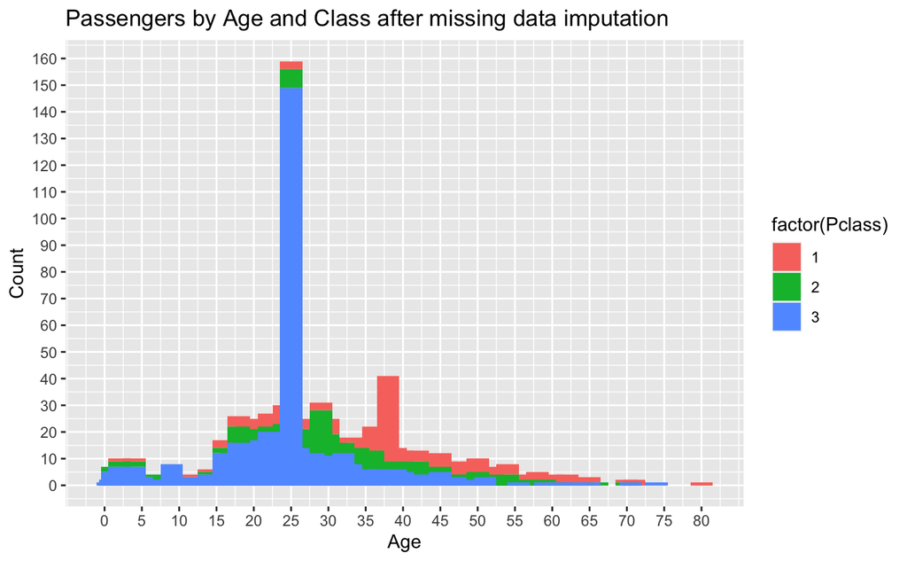

```r
ggplot(training_data, aes(x=ImputedAge)) + geom_bar(aes(fill=factor(Pclass)), width = 3) +
  scale_y_continuous(breaks = seq(min(0), max(160), by=10)) +
  scale_x_continuous(breaks = seq(min(0), max(80), by=5)) +
  xlab( 'Age' ) + ylab( 'Count' ) + ggtitle( 'Passengers by Age and Class after missing data imputation' )
```

# Tidy the data

Change the Survived, Pclass, and parentage variables from integers to factors:

```r
training_data$Survived <- factor(training_data$Survived)
training_data$Pclass <- factor(training_data$Pclass)
training_data$SibSp <- factor(training_data$SibSp)
```

```r
training_data$Parch <- factor(training_data$Parch)

# This was an unsuccessful attempt to fix the error:
# Error in model.frame.default(Terms, newdata, na.action = na.action, xlev = object$xlevels) : factor Parch has new levels 9

# l <- levels(training_data$Parch)
# n <- length(l)
# l[n+1] <- "9"
# levels(training_data$Parch) <- l

# Instead, I'm removing the single record where Parch was "9"
# Here is a better solution if we had power over splitting the training and test data:
# https://stackoverflow.com/questions/39721737/how-to-handle-errors-in-predict-function-of-r

str(training_data)
```

```
'data.frame':   891 obs. of  13 variables:
 $ PassengerId: int  1 2 3 4 5 6 7 8 9 10 ...
 $ Survived   : Factor w/ 2 levels "0","1": 1 2 2 2 1 1 1 1 2 2 ...
 $ Pclass     : Factor w/ 3 levels "1","2","3": 3 1 3 1 3 3 1 3 3 2 ...
 $ Name       : Factor w/ 891 levels "Abbing, Mr. Anthony",..: 109 191 358 277 16 559 520 629 417 581 ...
 $ Sex        : Factor w/ 2 levels "female","male": 2 1 1 1 2 2 2 2 1 1 ...
 $ Age        : num  22 38 26 35 35 NA 54 2 27 14 ...
 $ SibSp      : Factor w/ 7 levels "0","1","2","3",..: 2 2 1 2 1 1 1 4 1 2 ...
 $ Parch      : Factor w/ 7 levels "0","1","2","3",..: 1 1 1 1 1 1 1 2 3 1 ...
 $ Ticket     : Factor w/ 681 levels "110152","110413",..: 524 597 670 50 473 276 86 396 345 133 ...
 $ Fare       : num  7.25 71.28 7.92 53.1 8.05 ...
 $ Cabin      : Factor w/ 148 levels "","A10","A14",..: 1 83 1 57 1 1 131 1 1 1 ...
 $ Embarked   : Factor w/ 4 levels "","C","Q","S": 4 2 4 4 4 3 4 4 4 2 ...
 $ ImputedAge : num  22 38 26 35 35 25 54 2 27 14 ...
```

Remove the columns that we estimate not to need for now:

```r
training_data <- select(training_data, -Name, -Ticket, -Fare, -Cabin, -Age)
```

# Train the model with a Logistic Regression

```r
lr_model <- glm(formula = Survived ~ ., family = binomial(link = 'logit'), data = training_data)

summary(lr_model)
```

```
Call:
glm(formula = Survived ~ ., family = binomial(link = "logit"),
    data = training_data)

Deviance Residuals:
    Min       1Q   Median       3Q      Max
-2.7823  -0.6132  -0.4139   0.5748   2.5003

Coefficients:
              Estimate Std. Error z value Pr(>|z|)
(Intercept)  1.863e+01  1.661e+03   0.011  0.99105
PassengerId  5.236e-05  3.564e-04   0.147  0.88320
Pclass2     -1.197e+00  2.824e-01  -4.237 2.26e-05 ***
Pclass3     -2.326e+00  2.754e-01  -8.444  < 2e-16 ***
Sexmale     -2.685e+00  2.043e-01 -13.143  < 2e-16 ***
SibSp1       9.010e-02  2.240e-01   0.402  0.68747
SibSp2      -2.546e-01  5.394e-01  -0.472  0.63692
SibSp3      -2.146e+00  7.021e-01  -3.057  0.00224 **
SibSp4      -1.687e+00  7.644e-01  -2.206  0.02736 *
SibSp5      -1.591e+01  9.593e+02  -0.017  0.98677
SibSp8      -1.596e+01  7.569e+02  -0.021  0.98317
Parch1       3.967e-01  2.869e-01   1.383  0.16680
Parch2       9.285e-02  3.759e-01   0.247  0.80488
Parch3       3.806e-01  1.067e+00   0.357  0.72117
Parch4      -1.575e+01  1.044e+03  -0.015  0.98796
Parch5      -1.108e+00  1.172e+00  -0.945  0.34460
Parch6      -1.636e+01  2.400e+03  -0.007  0.99456
EmbarkedC   -1.457e+01  1.661e+03  -0.009  0.99300
EmbarkedQ   -1.456e+01  1.661e+03  -0.009  0.99300
EmbarkedS   -1.489e+01  1.661e+03  -0.009  0.99284
ImputedAge  -4.044e-02  8.748e-03  -4.622 3.80e-06 ***
---
Signif. codes:  0 ‘***’ 0.001 ‘**’ 0.01 ‘*’ 0.05 ‘.’ 0.1 ‘ ’ 1

(Dispersion parameter for binomial family taken to be 1)

    Null deviance: 1186.66  on 890  degrees of freedom
Residual deviance:  763.84  on 870  degrees of freedom
AIC: 805.84

Number of Fisher Scoring iterations: 15
```

According to this, it looks like the most significant variables and values are: `ImputedAge`, `Pclass` with vaules either 2 or 3 and `Sex` with value Male.

# Prepare Test Data

Before trying to predict the outcomes, we need to clean and tidy the test data in the same way that we did for the training data.

```r
test_data <- read.csv('data/test.csv')
head(test_data)
```

|  | PassengerId | Pclass | Name | Sex | Age | SibSp | Parch | Ticket | Fare | Cabin | Embarked |
| --- | --- | --- | --- | --- | --- | --- | --- | --- | --- | --- | --- |
| 1 | 892 | 3 | Kelly, Mr. James | male | 34.5 | 0 | 0 | 330911 | 7.8292 |  | Q |
| 2 | 893 | 3 | Wilkes, Mrs. James (Ellen Needs) | female | 47.0 | 1 | 0 | 363272 | 7.0000 |  | S |
| 3 | 894 | 2 | Myles, Mr. Thomas Francis | male | 62.0 | 0 | 0 | 240276 | 9.6875 |  | Q |
| 4 | 895 | 3 | Wirz, Mr. Albert | male | 27.0 | 0 | 0 | 315154 | 8.6625 |  | S |
| 5 | 896 | 3 | Hirvonen, Mrs. Alexander (Helga E Lindqvist) | female | 22.0 | 1 | 1 | 3101298 | 12.2875 |  | S |
| 6 | 897 | 3 | Svensson, Mr. Johan Cervin | male | 14.0 | 0 | 0 | 7538 | 9.2250 |  | S |

```r
str(test_data)
```

```
'data.frame':   418 obs. of  11 variables:
 $ PassengerId: int  892 893 894 895 896 897 898 899 900 901 ...
 $ Pclass     : int  3 3 2 3 3 3 3 2 3 3 ...
 $ Name       : Factor w/ 418 levels "Abbott, Master. Eugene Joseph",..: 210 409 273 414 182 370 85 58 5 104 ...
 $ Sex        : Factor w/ 2 levels "female","male": 2 1 2 2 1 2 1 2 1 2 ...
 $ Age        : num  34.5 47 62 27 22 14 30 26 18 21 ...
 $ SibSp      : int  0 1 0 0 1 0 0 1 0 2 ...
 $ Parch      : int  0 0 0 0 1 0 0 1 0 0 ...
 $ Ticket     : Factor w/ 363 levels "110469","110489",..: 153 222 74 148 139 262 159 85 101 270 ...
 $ Fare       : num  7.83 7 9.69 8.66 12.29 ...
 $ Cabin      : Factor w/ 77 levels "","A11","A18",..: 1 1 1 1 1 1 1 1 1 1 ...
 $ Embarked   : Factor w/ 3 levels "C","Q","S": 2 3 2 3 3 3 2 3 1 3 ...
```

We can see from the structure output that there are about half less data points in the test dataset as in the training dataset.

## Missing test data

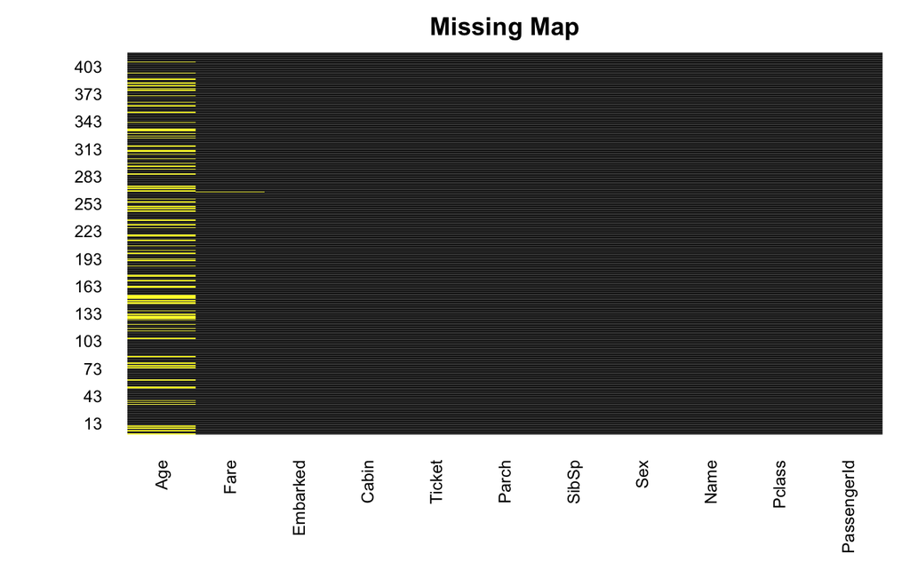

```r
Amelia::missmap(test_data, main = "Missing Map", col = c('yellow', 'black'), legend=FALSE)
```

Unlike the training dataset, the test dataset also has missing values in the Fares variables. In our case, this will not affect much our results because we do not use that variale for our model.

In the Age column, the proportion of missing data is slightly larger than in the training dataset:

```r
proportion <- round(nrow(test_data[is.na(test_data$Age),]) * 100 /  nrow(test_data) , 2)
paste0("The proportion of missing values in the Age column is: ", proportion , " %" )
```

```
[1] "The proportion of missing values in the Age column is: 20.57 %"
```

We’ll now also impute the missing Age values for the test data, using the same functions that we used for the training data:

```r
ImputedAge <- impute_age(test_data, test_data$Age, test_data$Pclass)
if( !('ImputedAge' %in% colnames(test_data)) ){
  test_data <- cbind(test_data, ImputedAge)
}
```

## Tidy the test data

```r
test_data$Pclass <- factor(test_data$Pclass)
test_data$SibSp <- factor(test_data$SibSp)
test_data$Parch <- factor(test_data$Parch)
str(test_data)
```

```
'data.frame':   418 obs. of  12 variables:
 $ PassengerId: int  892 893 894 895 896 897 898 899 900 901 ...
 $ Pclass     : Factor w/ 3 levels "1","2","3": 3 3 2 3 3 3 3 2 3 3 ...
 $ Name       : Factor w/ 418 levels "Abbott, Master. Eugene Joseph",..: 210 409 273 414 182 370 85 58 5 104 ...
 $ Sex        : Factor w/ 2 levels "female","male": 2 1 2 2 1 2 1 2 1 2 ...
 $ Age        : num  34.5 47 62 27 22 14 30 26 18 21 ...
 $ SibSp      : Factor w/ 7 levels "0","1","2","3",..: 1 2 1 1 2 1 1 2 1 3 ...
 $ Parch      : Factor w/ 8 levels "0","1","2","3",..: 1 1 1 1 2 1 1 2 1 1 ...
 $ Ticket     : Factor w/ 363 levels "110469","110489",..: 153 222 74 148 139 262 159 85 101 270 ...
 $ Fare       : num  7.83 7 9.69 8.66 12.29 ...
 $ Cabin      : Factor w/ 77 levels "","A11","A18",..: 1 1 1 1 1 1 1 1 1 1 ...
 $ Embarked   : Factor w/ 3 levels "C","Q","S": 2 3 2 3 3 3 2 3 1 3 ...
 $ ImputedAge : num  34.5 47 62 27 22 14 30 26 18 21 ...
```

```r
test_data <- dplyr::select(test_data, - c("Name", "Ticket", "Fare", "Cabin", "Age"))
str(test_data)
```

```
'data.frame':   418 obs. of  7 variables:
 $ PassengerId: int  892 893 894 895 896 897 898 899 900 901 ...
 $ Pclass     : Factor w/ 3 levels "1","2","3": 3 3 2 3 3 3 3 2 3 3 ...
 $ Sex        : Factor w/ 2 levels "female","male": 2 1 2 2 1 2 1 2 1 2 ...
 $ SibSp      : Factor w/ 7 levels "0","1","2","3",..: 1 2 1 1 2 1 1 2 1 3 ...
 $ Parch      : Factor w/ 8 levels "0","1","2","3",..: 1 1 1 1 2 1 1 2 1 1 ...
 $ Embarked   : Factor w/ 3 levels "C","Q","S": 2 3 2 3 3 3 2 3 1 3 ...
 $ ImputedAge : num  34.5 47 62 27 22 14 30 26 18 21 ...
```

```r
temp_test_data <- test_data[test_data$Parch !=9,]
```

Now the test dataset is ready to be used for our predictions.

# Prediction

```r
fitted_probabilities <- predict(lr_model, temp_test_data, type='response')
fitted_results <- ifelse(fitted_probabilities > 0.5, 1,0)
temp_test_data <- cbind(temp_test_data, fitted_results)
head(temp_test_data)
```

|  | PassengerId | Pclass | Sex | SibSp | Parch | Embarked | ImputedAge | fitted_results |
| --- | --- | --- | --- | --- | --- | --- | --- | --- |
| 1 | 892 | 3 | male | 0 | 0 | Q | 34.5 | 0 |
| 2 | 893 | 3 | female | 1 | 0 | S | 47.0 | 0 |
| 3 | 894 | 2 | male | 0 | 0 | Q | 62.0 | 0 |
| 4 | 895 | 3 | male | 0 | 0 | S | 27.0 | 0 |
| 5 | 896 | 3 | female | 1 | 1 | S | 22.0 | 1 |
| 6 | 897 | 3 | male | 0 | 0 | S | 14.0 | 0 |

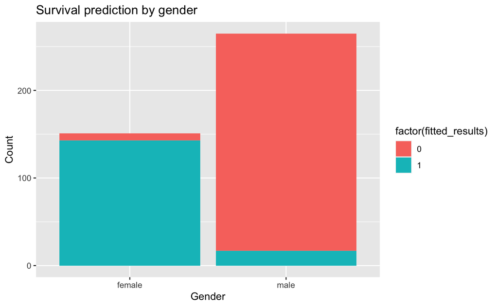

```r
ggplot(temp_test_data, aes(x=Sex)) + geom_bar(aes(fill=factor(fitted_results))) +
  xlab( 'Gender' ) + ylab( 'Count' ) + ggtitle( 'Survival prediction by gender' )
```

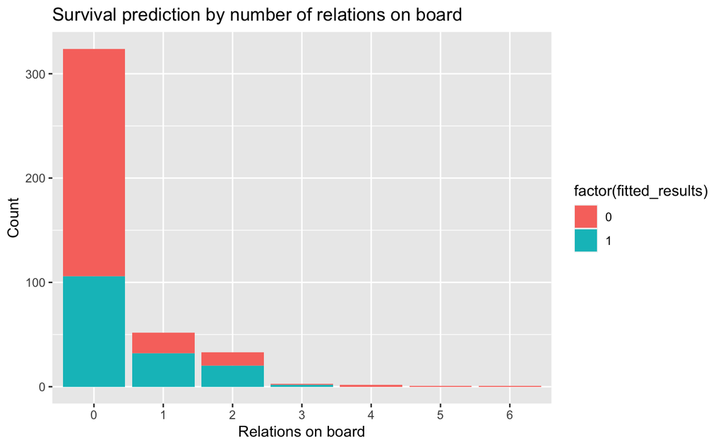

```r
ggplot(temp_test_data, aes(x=Parch)) + geom_bar(aes(fill=factor(fitted_results))) +
  xlab( 'Relations on board' ) + ylab( 'Count' ) + ggtitle( 'Survival prediction by number of relations on board' )
```

# Evaluation

```r
# We can't find the missclassification error because the test data does not have the Survive column.
# If we did, we would calculated with this:
# misClassError <- mean(fitted.results != test_data$Survived)
# The Accuracy is:
# print( 1 - misClassError )
# From here, we can view the confusion matrix:
# table(test_data$Survived, fitted_probabilities>0.5)
```